# 405314668_stats102a_hw1

**Pseudocode**

1. Create a function that inputs a numeric vector
2. Error handle: if there are one or more element in the input vector is not numeric, output an error
3. Obtain the largest element from the input vector and assign it to a name.
4. Create a sequence of values from 2 until the largest value of the input vector and assign it to a name: “start”
5. Starting at index 2, check if the index value is equal to any element of the “start” vector
6. If the index value is equal to any element of the “start” vector: -find the multiples of this index value by calculating the mod of “start” and the index that have a remainder of zero. -assign these multiples to a name “index_multiples” -find the elements in the “start” vector that are NOT in the “index_multiples” vector -concantenate those values with the index value and reassign it to the “start” vector -move on to the next index -Note: This will create a vector of prime numbers up to the largest value in your input vector
7. When the last index is run, check if each elements in your input vector is in the “start” vector of prime numbers.

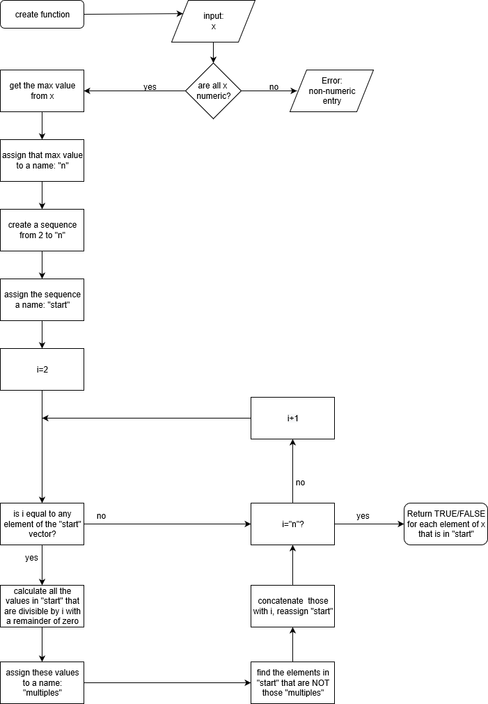

Flowchart for Checking if a Number is Prime

```r
is_prime
```

```
## function(x) {
## #Take a numeric vector x and return a logical vector if the input value is a prime number.
## #Args:
## #x: type numeric, vector with no dimensions
## #Return:
## #type logical, vector with no dimensions
##   if (!all(is.numeric(x))){
##     stop("The input is not numeric")
##   }
##   n <- max(x)
##   start <- seq(2, length.out=n-1)
##   for(i in seq(2, length.out=n-1)){
##     if(any(i == start)){
##       i_multiples <- (start %% i) == 0
##       start <- c(start[!i_multiples], i)
##     }
##   }
##   x %in% start
## }
## <bytecode: 0x000000001abd2160>
```

```r
# Test the function: should get FALSE
is_prime(9)
```

```
## [1] FALSE
```

```r
# Test the function: should get T, T, T, F, F, F, F, F
is_prime(c(2, 97, 23, 51, 119, -1, 0, 1.5))
```

```
## [1]  TRUE  TRUE  TRUE FALSE FALSE FALSE FALSE FALSE
```

4. Write a function get_factors() which takes a positive integer x and returns the vector of (not mecessarily unique) prime factors of x.

**Pseudocode**

1. Create a function that inputs a positive integer.
2. Error handle the inputs that are not positive integers by: -if argument is not numeric, output an error. -if argument is less than or equal to zero, output an error. -if argument is not an interger, output an error. -Note: an integer divided by itself will equal 1.
3. start a counter at zero.
4. create an empty vector.
5. starting an index at 2, check if the input integer is divisable by 2 with a reaminder of 0.
6. If the input value is divisable by the index with a remainder of 0: -increase the counter by 1 -in the empty numeric vector, using the counter as the element placeholder, assign the index value to the “counter” element of the vector -divide the input value by the index and override the old input value to this new one -check if the new input value is divisible by the index. If it is, repeat step f. If it is not, move on to step g.
7. If it is NOT divisable, move on to the next index, and repeat step f.
8. When the last index is reached, and the loop has ran, print out the vector that the possible index values were being assigned to.

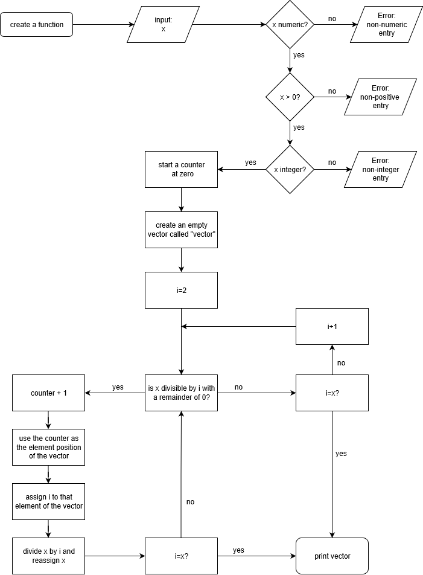

Flowchart to Get Prime Factors

```r
get_factors
```

```
## function(x) {
## #Take a positive integer x and returns the vector of prime factors of x.
## #Args:
## #x: type interger, no dimensions
## #Return:
## #type double, vector with no dimensions
##   if(!is.numeric(x)){
##     stop("The input is not numeric")
##   }
##   if (x <= 0) {
##     stop("The input is less than or equal to zero")
##   }
##   if ((x / as.integer(x)) != 1) {
##     stop("The input is not an integer")
##   }
##   count <- 0
##   vector <- numeric(0)
##   for (i in 2:x) {
##     if(x %% i == 0) {
##       repeat{
##       count <- count + 1
##       vector[count] <- i
##       x <- x/i
##       if(!(x %% i == 0)) {break}
##       }
##     }
##   }
##   vector
## }
## <bytecode: 0x000000001f8d2050>
```

```r
# Test the function: should get 2, 2, 3
get_factors(12)
```

```
## [1] 2 2 3
```

```r
# Test the function: should get 2, 2, 2, 3, 3, 5, 5
get_factors(1800)
```

```
## [1] 2 2 2 3 3 5 5
```

```r
# Test the function: should get 7, 13, 19, 19
get_factors(32851)
```

```
## [1]  7 13 19 19
```

```r
# Test the function: should get 9587
get_factors(9587)
```

```
## [1] 9587
```

```r
# Test the function: should get ERROR
try(get_factors(-280))
```

```
## Error in get_factors(-280) : The input is less than or equal to zero
```

```r
# Test the function: should get ERROR
try(get_factors(280.75))
```

```
## Error in get_factors(280.75) : The input is not an integer
```